# Exploratory Data Analysis ~ R Coursera Project

Data on Individual Household Electric Power Consumption

Shibani S Otis

8/21/2020

### Introduction

This assignment uses data from the UC Irvine Machine Learning Repository, a popular repository for machine learning datasets. In particular, we will be using the “Household Electric Power Consumption” dataset which measures the electric power consumption in one household with a one-minute sampling rate over a period of almost 4 years. Different electrical quantities and some sub-metering values are available.

The following descriptions of the 9 variables in the dataset are taken from the UCI web site:

1. **Date**: Date in format dd/mm/yyyy
2. **Time**: time in format hh:mm:ss
3. **Global_active_power**: household global minute-averaged active power (in kilowatt)
4. **Global_reactive_power**: household global minute-averaged reactive power (in kilowatt)
5. **Voltage**: minute-averaged voltage (in volt)
6. **Global_intensity**: household global minute-averaged current intensity (in ampere)
7. **Sub_metering_1**: energy sub-metering No. 1 (in watt-hour of active energy). It corresponds to the kitchen, containing mainly a dishwasher, an oven and a microwave (hot plates are not electric but gas powered).
8. **Sub_metering_2**: energy sub-metering No. 2 (in watt-hour of active energy). It corresponds to the laundry room, containing a washing-machine, a tumble-drier, a refrigerator and a light.
9. **Sub_metering_3**: energy sub-metering No. 3 (in watt-hour of active energy). It corresponds to an electric water-heater and an air-conditioner.

The dataset has 2,075,259 rows and 9 columns. We will only be using data from the dates 2007-02-01 and 2007-02-02.

### Data Processing

Let’s load the electric power consumption data:

```r
# Note: Missing values are coded in as "?" in this data set
powerData <- read.table("household_power_consumption.txt", header = T, sep = ";", na.strings = "?", colClasses = c("character", "character", rep("numeric", 7)))

head(powerData)
```

```
##         Date     Time Global_active_power Global_reactive_power Voltage
## 1 16/12/2006 17:24:00               4.216                 0.418  234.84
## 2 16/12/2006 17:25:00               5.360                 0.436  233.63
## 3 16/12/2006 17:26:00               5.374                 0.498  233.29
## 4 16/12/2006 17:27:00               5.388                 0.502  233.74
## 5 16/12/2006 17:28:00               3.666                 0.528  235.68
## 6 16/12/2006 17:29:00               3.520                 0.522  235.02
##   Global_intensity Sub_metering_1 Sub_metering_2 Sub_metering_3
## 1             18.4              0              1             17
## 2             23.0              0              1             16
## 3             23.0              0              2             17
## 4             23.0              0              1             17
## 5             15.8              0              1             17
## 6             15.0              0              2             17
```

Since we will only be using data from 2007-02-01 and 2007-02-02, we need to subset the data:

```r
# We need an "OR" operator i.e. | when using subset. Note, concatenate doesn't work here!
subsetFeb <- subset(powerData, Date == "1/2/2007" | Date == "2/2/2007")

head(subsetFeb)
```

```
##           Date     Time Global_active_power Global_reactive_power Voltage
## 66637 1/2/2007 00:00:00               0.326                 0.128  243.15
## 66638 1/2/2007 00:01:00               0.326                 0.130  243.32
## 66639 1/2/2007 00:02:00               0.324                 0.132  243.51
## 66640 1/2/2007 00:03:00               0.324                 0.134  243.90
## 66641 1/2/2007 00:04:00               0.322                 0.130  243.16
## 66642 1/2/2007 00:05:00               0.320                 0.126  242.29
##       Global_intensity Sub_metering_1 Sub_metering_2 Sub_metering_3
## 66637              1.4              0              0              0
## 66638              1.4              0              0              0
## 66639              1.4              0              0              0
## 66640              1.4              0              0              0
## 66641              1.4              0              0              0
## 66642              1.4              0              0              0
```

Now let’s plot our first plot, a histogram and save it as a PNG file with a width of 480 pixels and a height of 480 pixels:

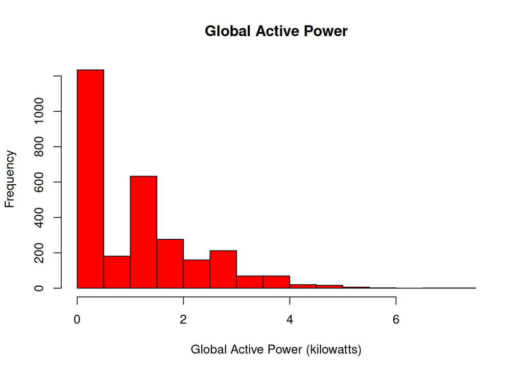

```r
# First we need to specify where we want to save the plot
#png(file="~/Documents/Coursera Data Science Specialization: Using R/Coursera Projects/Exploratory Data Analysis/plot1.png", width = 480, height = 480)

# Then we run the plot we want to save
hist(subsetFeb$Global_active_power, col = "red", xlab = "Global Active Power (kilowatts)", main = "Global Active Power")
```

```r
# Lastly, turn the PNG graphics device off
#dev.off()
```

Now we need to convert the “Date” and “Time” columns to the appropriate format:

```r
# Created a new column which took dates & times from the subset data, formatted into POSIXct
subsetFeb$DateTime <- as.POSIXct(paste(subsetFeb$Date, subsetFeb$Time), format = "%d/%m/%Y %H:%M:%S")

# Alternatively, we could have used the "strptime" function which uses POSIXlt:
#subsetFeb$DateTime <- strptime(paste(subsetFeb$Date, subsetFeb$Time), format = "%d/%m/%Y %H:%M:%S")

# Re-ordered the columns in the data set
powerFinal <- subsetFeb[ ,c(1,2,10,3:9)]

head(powerFinal)
```

```
##           Date     Time            DateTime Global_active_power
## 66637 1/2/2007 00:00:00 2007-02-01 00:00:00               0.326
## 66638 1/2/2007 00:01:00 2007-02-01 00:01:00               0.326
## 66639 1/2/2007 00:02:00 2007-02-01 00:02:00               0.324
## 66640 1/2/2007 00:03:00 2007-02-01 00:03:00               0.324
## 66641 1/2/2007 00:04:00 2007-02-01 00:04:00               0.322
## 66642 1/2/2007 00:05:00 2007-02-01 00:05:00               0.320
##       Global_reactive_power Voltage Global_intensity Sub_metering_1
## 66637                 0.128  243.15              1.4              0
## 66638                 0.130  243.32              1.4              0
## 66639                 0.132  243.51              1.4              0
## 66640                 0.134  243.90              1.4              0
## 66641                 0.130  243.16              1.4              0
## 66642                 0.126  242.29              1.4              0
##       Sub_metering_2 Sub_metering_3
## 66637              0              0
## 66638              0              0
## 66639              0              0
## 66640              0              0
## 66641              0              0
## 66642              0              0
```

The second plot is a line graph. Let’s save this plot as a 480 pixels by 480 pixels PNG:

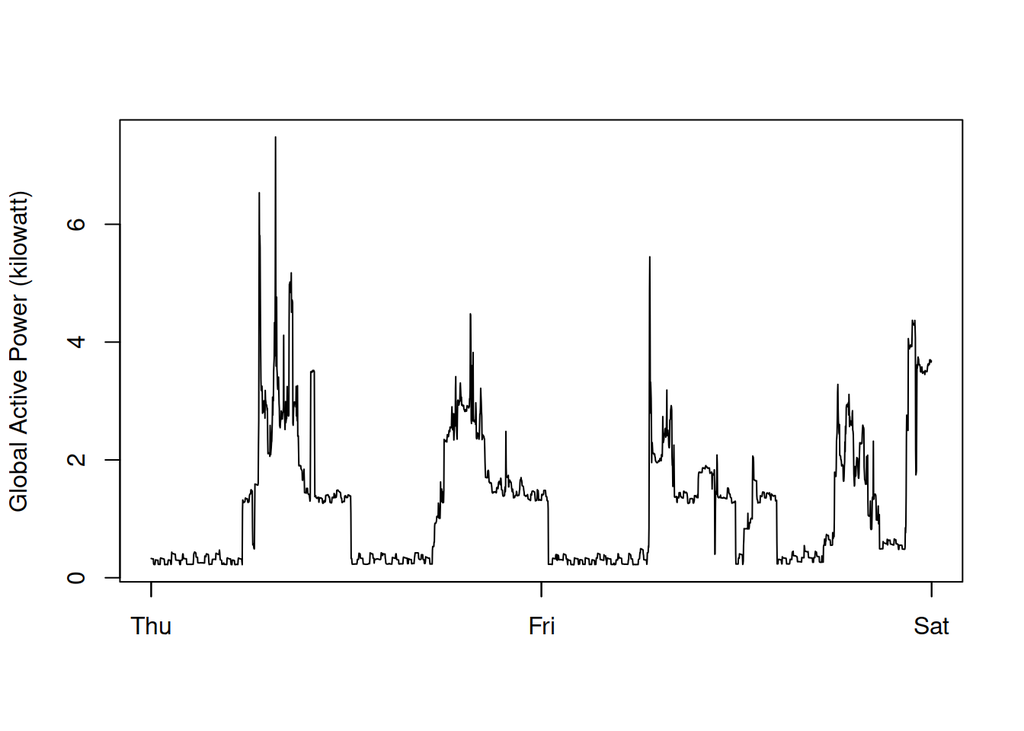

```r
#png(file="~/Documents/Coursera Data Science Specialization: Using R/Coursera Projects/Exploratory Data Analysis/plot2.png", width = 480, height = 480)

plot(powerFinal$DateTime, powerFinal$Global_active_power, type = "l", xlab = "", ylab = "Global Active Power (kilowatt)")
```

```r
#dev.off()
```

Now to make the third plot and save as a PNG:

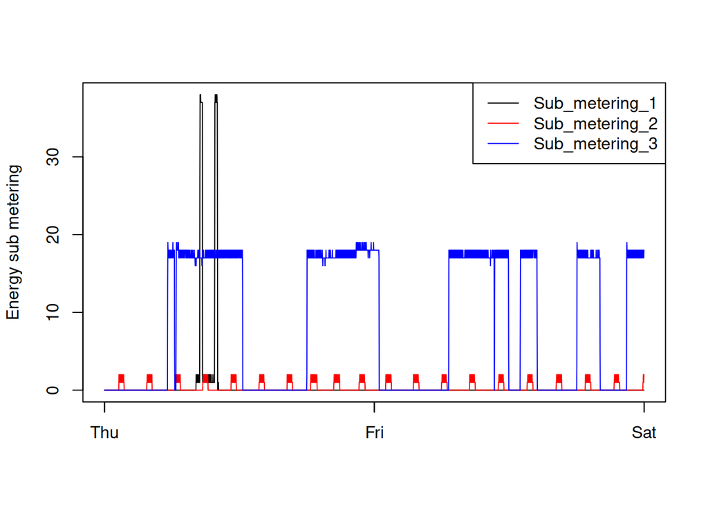

```r
#png(file="~/Documents/Coursera Data Science Specialization: Using R/Coursera Projects/Exploratory Data Analysis/Project 1 Plots/plot3.png", width = 480, height = 480)

plot(powerFinal$DateTime, powerFinal$Sub_metering_1, type = "l", xlab = "", ylab = "Energy sub metering")

# We need to add additional lines to the plot, thus we use the "lines" function instead of "plot"
lines(powerFinal$DateTime, powerFinal$Sub_metering_2, type = "l", col = "red", xlab = "", ylab = "Energy sub metering")
lines(powerFinal$DateTime, powerFinal$Sub_metering_3, type = "l", col = "blue", xlab = "", ylab = "Energy sub metering")

# Created a legend
legend("topright", lty = 1, col = c("black", "red", "blue"), legend = c("Sub_metering_1", "Sub_metering_2", "Sub_metering_3"))
```

```r
#dev.off()
```

The last plot consists of the 2nd and 3rd plots, along with two other plots saved as a PNG file:

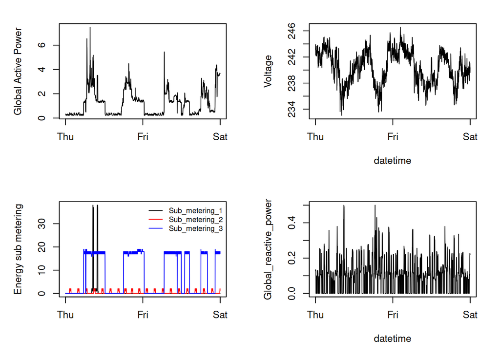

```r
#png(file="~/Documents/Coursera Data Science Specialization: Using R/Coursera Projects/Exploratory Data Analysis/plot4.png", width = 480, height = 480)

# We need 2 rows and 2 columns for our plots and an appropriate margin to fit them all
par(mfcol = c(2,2), mar = c(5,5,2,2))

plot(powerFinal$DateTime, powerFinal$Global_active_power, type = "l", xlab = "", ylab = "Global Active Power")

plot(powerFinal$DateTime, powerFinal$Sub_metering_1, type = "l", xlab = "", ylab = "Energy sub metering")
lines(powerFinal$DateTime, powerFinal$Sub_metering_2, type = "l", col = "red", xlab = "", ylab = "Energy sub metering")
lines(powerFinal$DateTime, powerFinal$Sub_metering_3, type = "l", col = "blue", xlab = "", ylab = "Energy sub metering")
legend("topright", lty = 1, col = c("black", "red", "blue"), legend = c("Sub_metering_1", "Sub_metering_2", "Sub_metering_3"), cex = 0.75, bty = "n")   # bty ="n" removes box around the legend; cex reduces its size

plot(powerFinal$DateTime, powerFinal$Voltage, type = "l", xlab = "datetime", ylab = "Voltage")

plot(powerFinal$DateTime, powerFinal$Global_reactive_power, type = "l", xlab = "datetime", ylab = "Global_reactive_power")
```

```r
#dev.off()
```